# Cluster Analysis

WDI Indicators

Benyamin jami al ahmadi 94105282

2018-07-20 18:55:42

> با توجه به داده بانک جهانی به سوالات زیر پاسخ دهید. برای استفاده از داده از سه فایل زیر استفاده نمایید. داده نام کشورها: WDICountry داده نام سری های زمانی: WDISeries داده کل: WDIData در صورتی که داده را در اختیار ندارید می توانید از بسته WDI استفاده نموده و داده های مورد نظر را استخراج نمایید.

```r
library(stringr)
library(readr)
library(tidyr)
library(highcharter)
library(ggplot2)
library(ggthemes)
library(countrycode)
library(ggpubr)
library(ggbiplot)
library(dplyr)

series = read_csv('../data/WDISeries.csv')
country = read_csv('../data/WDICountry.csv')
data = read_csv('../data/WDIData.csv')
```

۱. ده کشور فقیر دنیا را بیابید. نمودار درآمد روزانه آنها را رسم کنید. چند درصد از اعضای این کشورها زیر خط فقر هستند؟ متوسط عمر در این کشورها چقدر است؟

```r
data %>% filter(`Indicator Code` == "NY.GDP.PCAP.PP.KD") %>% gather('year','val',`1960`:`2017`) %>% filter(!is.na(val)) %>%
  mutate(year = as.numeric(year)) %>% arrange(year) %>% group_by(`Country Name`) %>% summarise(poverty = last(val)) %>%
  arrange(poverty) %>% head(10) %>% select(1) -> poorestCountry
poorestCountry
```

```
## # A tibble: 10 x 1
##    `Country Name`
##    <chr>
##  1 Central African Republic
##  2 Burundi
##  3 Liberia
##  4 Congo, Dem. Rep.
##  5 Niger
##  6 Malawi
##  7 Mozambique
##  8 Sierra Leone
##  9 Comoros
## 10 Madagascar
```

```r
poorestCountry %>% left_join(data) -> poorestCountry
```

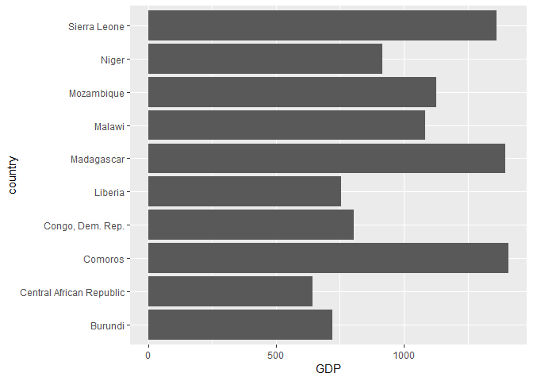

```r
poorestCountry %>% filter(`Indicator Code` == "NY.GDP.PCAP.PP.KD") %>% select(country = `Country Name` , GDP = `2016`) %>% ggplot(aes(x = country , y = GDP)) + geom_bar(stat = "identity") + coord_flip()
```

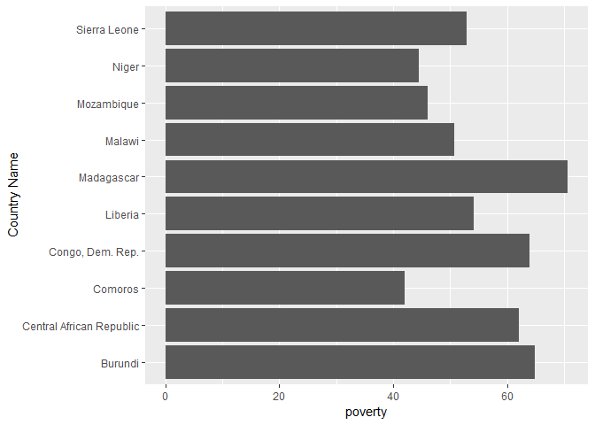

```r
poorestCountry %>% filter(`Indicator Code` == "SI.POV.NAHC") %>% gather('year','val',`1960`:`2017`) %>% filter(!is.na(val)) %>%
  mutate(year = as.numeric(year)) %>% arrange(year) %>% group_by(`Country Name`) %>% summarise(poverty = last(val)) %>%
  ggplot(aes(x = `Country Name` , y = poverty)) + geom_bar(stat = "identity") + coord_flip()
```

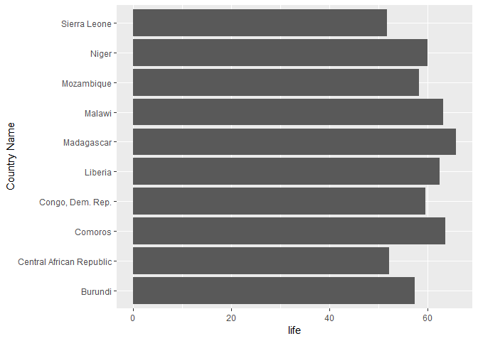

```r
poorestCountry %>% filter(`Indicator Code` == "SP.DYN.LE00.IN") %>% gather('year','val',`1960`:`2017`) %>% filter(!is.na(val)) %>%
  mutate(year = as.numeric(year)) %>% arrange(year) %>% group_by(`Country Name`) %>% summarise(life = last(val)) %>%
  ggplot(aes(x = `Country Name` , y = life)) + geom_bar(stat = "identity") + coord_flip()
```

۲. تراژدی روآندا: بر اساس داده های امید به زندگی ابتدا نمودار سالانه نمودار جعبه ایی امید به زندگی کشورها را رسم نمایید(در یک نمودار!). سپس سری زمانی امید به زندگی روآندا را به آن اضافه کنید. چه می بینید؟ چند میلیون نفر کشته شدند؟

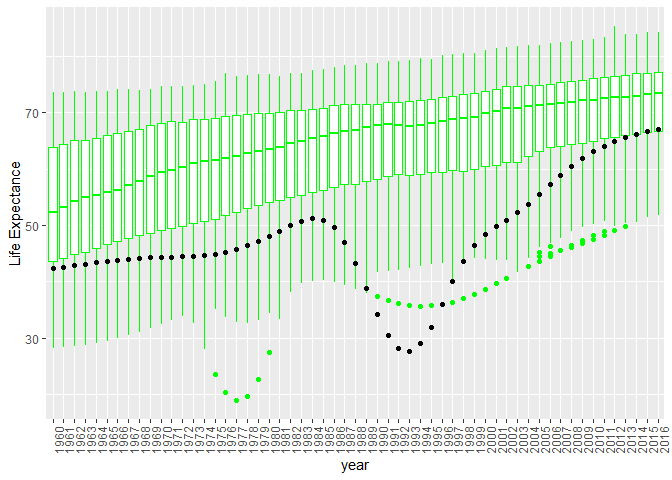

```r
data %>% filter(`Indicator Code` == "SP.DYN.LE00.IN") %>% gather('year','val',`1960`:`2017`) %>% filter(!is.na(val)) -> t2
  ggplot() + geom_boxplot(data = t2 ,aes(year, val), color = "green") + geom_point(data = t2 %>% filter(`Country Name` == "Rwanda"),aes(x = year, y = val)) + theme(axis.text.x = element_text(angle = 90, hjust = 1)) + ylab("Life Expectance")
```

در جریان نسل کشی سال ۱۹۹۴ روآندا که از آن تحت عنوان تاریک ترین فاجعه انسانی نیم سده گذشته یاد می شود، علاوه بر کشته شدن ۸۰۰ هزار مرد، زن و کودک، به ۲۰۰ تا ۵۰۰ هزار زن تجاوز جنسی شد.

۳. نمودار امید به زندگی و هزینه های بهداشتی را رسم کنید. چه نتیجه ایی می گیرید؟

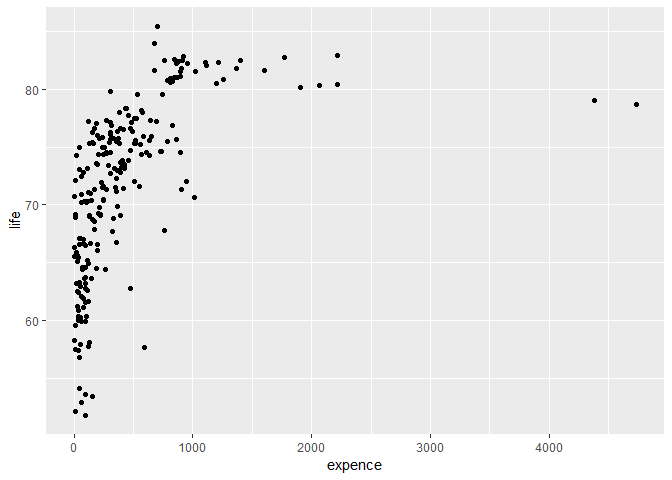

```r
data %>% filter(`Indicator Code` == "SH.XPD.PVTD.PP.CD") %>% gather('year','val',`1960`:`2017`) %>% filter(!is.na(val)) %>%
  mutate(year = as.numeric(year)) %>% arrange(year) %>% group_by(`Country Code`) %>% summarise(expence = last(val)) %>%
  arrange(expence) -> expence
data %>% filter(`Indicator Code` == "SP.DYN.LE00.IN") %>% gather('year','val',`1960`:`2017`) %>% filter(!is.na(val)) %>%
  mutate(year = as.numeric(year)) %>% arrange(year) %>% group_by(`Country Code`) %>% summarise(life = last(val)) %>%
  arrange(life) -> life
merge(life,expence) -> t3
ggplot() + geom_point(data = t3 , aes(y = life , x = expence))
```

با افزایش هزینه های بهداشتی کیفیت خدمات بهداشتی افزایش میابد که در نتیجه امید به زندگی افزایش پیدا کرده.

۴. آیا قدرت خرید خانواده های ایرانی در ۵۰ سال اخیر افزایش یافته است؟ برای این کار از داده های اقتصادی خانوار استفاده کنید.

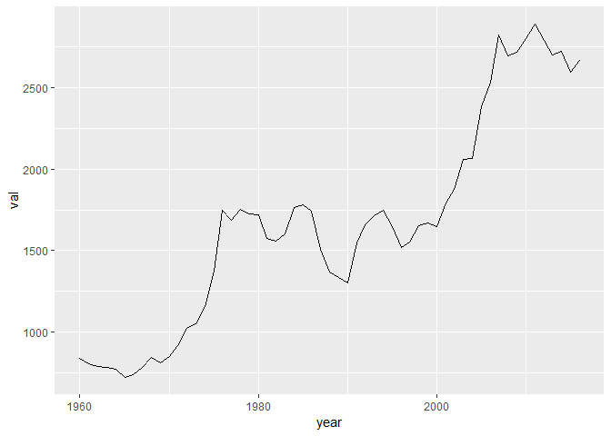

```r
data %>% filter(`Indicator Code` == "NE.CON.PRVT.PC.KD" , `Country Name` == "Iran, Islamic Rep.") %>% gather('year','val',`1960`:`2017`) %>% filter(!is.na(val)) %>%
  mutate(year = as.numeric(year)) %>% arrange(year) -> t4
t4 %>% ggplot(aes(x = year, y = val)) + geom_line()
```

با توجه به نمودار قدرت خرید خانواده های ایران افزایش یافته.

۵. رشد اقتصادی ایران را با کشورهای دیگر در طول ۲۰ سال گذشته بر حسب بیست شاخص های اقتصادی مهم مانند تولید ناخالص ملی، تورم و … ارزیابی کنید! (برای هر شاخص از تصویرسازی استفاده کنید.)

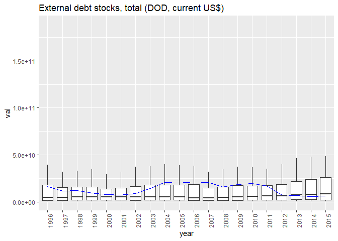

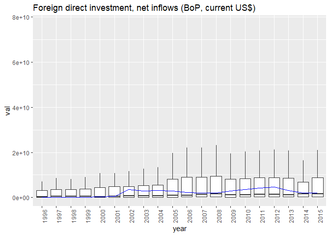

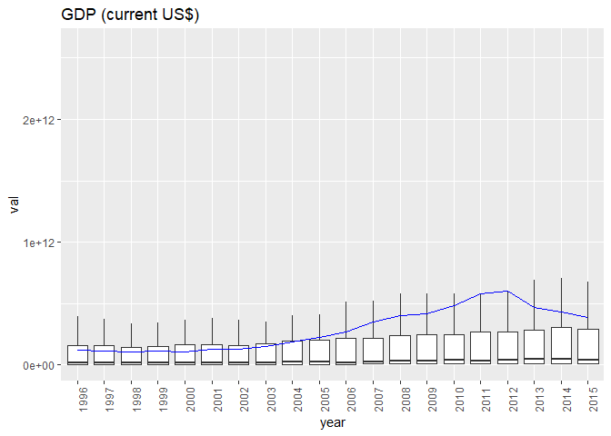

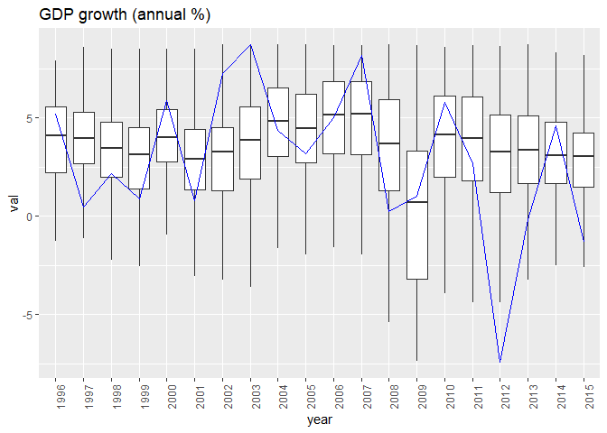

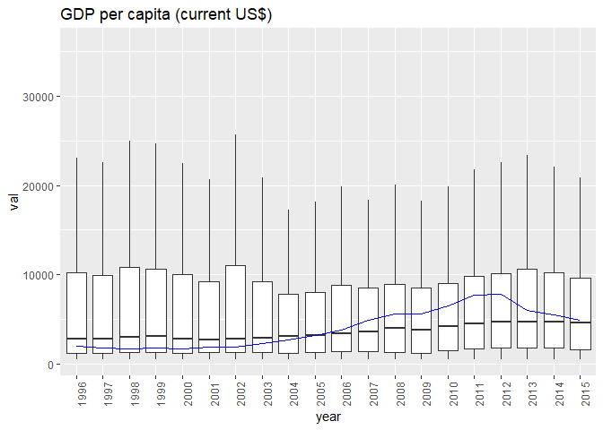

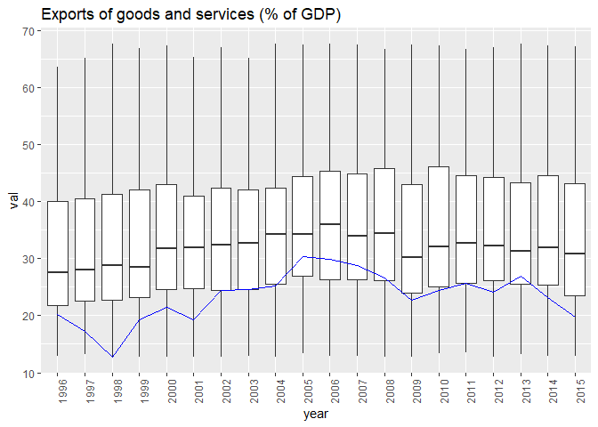

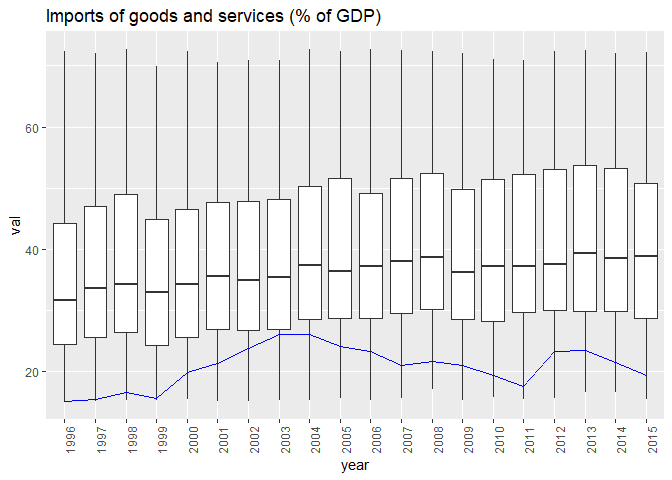

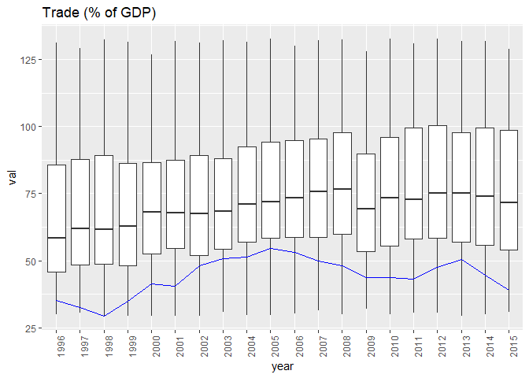

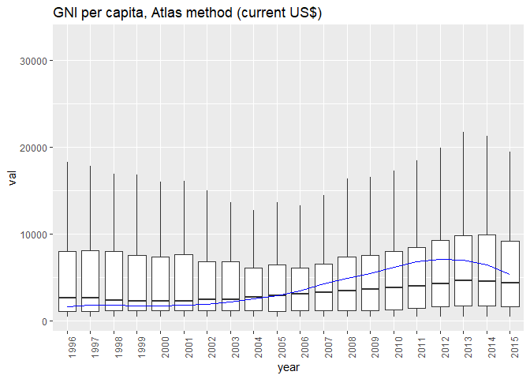

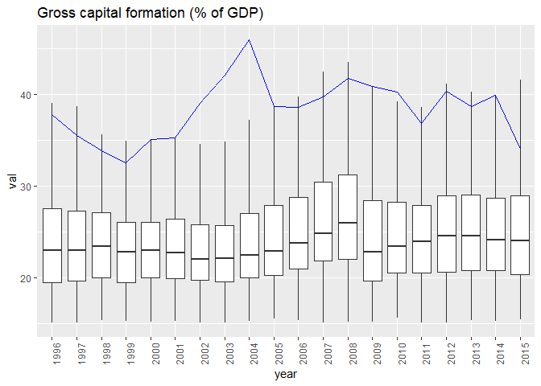

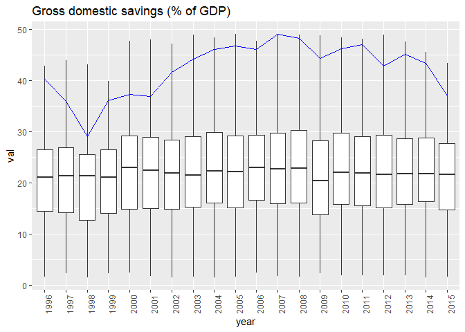

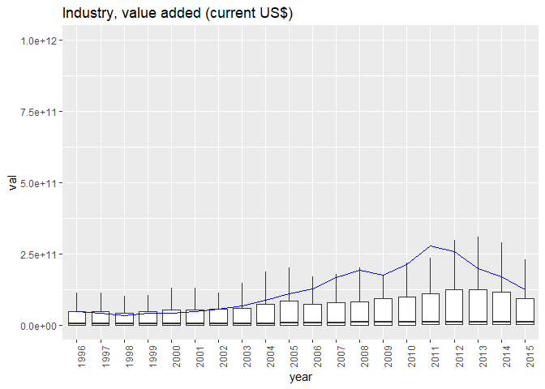

[8 more figures not shown]

```r
 Indicatortemp = c(
  "NY.ADJ.SVNG.GN.ZS",
  "EA.PRD.AGRI.KD",
  "GC.DOD.TOTL.GD.ZS",
  "BM.GSR.ROYL.CD",
  "BX.GSR.ROYL.CD",
  "BN.CAB.XOKA.CD",
  "GC.XPN.TOTL.GD.ZS",
  "BX.GSR.TOTL.CD",
  "DT.DOD.DECT.CD",
  "DT.DOD.DECT.GN.ZS",
  "BX.KLT.DINV.CD.WD",
  "NY.GDP.MKTP.CD",
  "NY.GDP.MKTP.KD.ZG",
  "NY.GDP.PCAP.CD",
  "NE.EXP.GNFS.ZS",
  "NE.IMP.GNFS.ZS",
  "NE.TRD.GNFS.ZS",
  "NY.GNP.PCAP.CD",
  "NE.GDI.TOTL.ZS",
  "NY.GDS.TOTL.ZS",
  "NV.IND.TOTL.CD",
  "NV.IND.MANF.CD",
  "NY.GDP.PCAP.KD.ZG",
  "NY.GDP.PCAP.PP.CD",
  "NY.GNP.PCAP.PP.KD",
  "NY.GNP.ATLS.CD",
  "NY.GNP.MKTP.PP.CD",
  "NY.ADJ.AEDU.GN.ZS",
  "BX.KLT.DINV.WD.GD.ZS",
  "NV.AGR.TOTL.ZS",
  "NV.SRV.TETC.ZS",
  "NY.GSR.NFCY.CD",
  "NE.CON.TETC.CD",
  "NE.DAB.TOTL.CD",
  "SL.UEM.TOTL.ZS",
  "FP.CPI.TOTL.ZG",
  "NY.ADJ.DMIN.GN.ZS"
)
k = 0;
 Indicator = c()
for(code in  Indicatortemp){
  if(k == 20)
    break();
  IndicatorName = series %>% filter(`Series Code` == code) %>% .$`Indicator Name` %>% .[1]
  worldData = data %>% filter(`Indicator Code` == code) %>% select(`Country Name` , `1996`:`2015`) %>% gather('year','val',`1996`:`2015`) %>% filter(!is.na(val))
  IranData = worldData %>% filter(`Country Name` == "Iran, Islamic Rep.")
  if(length(IranData$val) < 20)
    next()
  p = ggplot() + geom_boxplot(data = worldData,aes(x = year,y=val),outlier.colour = NA) +
    geom_line(data = IranData,aes(x=year,y=val,group = 1),color = "blue") +
    theme(axis.text.x = element_text(angle = 90, hjust = 1)) +
    ggtitle(IndicatorName) +
    scale_y_continuous(limits = c(min(quantile(worldData$val, 0.1),min(IranData$val)),max(quantile(worldData$val, 0.9),max(IranData$val))))
  print(p)
   Indicator = c(code ,  Indicator)
  k = k + 1
}
```

۶. در قسمت قبل با استفاده از روش خوشه بندی k-means داده ها را به سه دسته تقسیم کنید. ایران در کدام دسته می گنجد؟ (پیش از خوشه بندی طبیعتا داده را باید پاکسازی و استاندارد سازی نمایید.)

```r
data %>% filter(`Indicator Code` %in%  Indicator) %>% gather('year','val',`1960`:`2017`) %>% filter(!is.na(val)) %>%
  mutate(year = as.numeric(year)) %>% arrange(year) %>% group_by(`Country Name`,`Indicator Code`) %>% summarise(val = last(val)) %>% spread('Indicator Code','val') %>% drop_na() -> worldData
worldData %>% .[,-1] %>% scale() %>% kmeans(centers = 3,nstart = 20) %>% .$cluster %>%
  data.frame(Country = worldData$`Country Name`,cluster = .) -> clustered
cluster1 = ""
cluster2 = ""
cluster3 = ""
for(i in 1:length(clustered$Country)){
  if(clustered[i,2] == 1){
    cluster1 = paste(clustered[i,1],cluster1,sep = " , ")
  }
  if(clustered[i,2] == 2){
    cluster2 = paste(clustered[i,1],cluster2,sep = " , ")
  }
  if(clustered[i,2] == 3){
    cluster3 = paste(clustered[i,1],cluster3,sep = " , ")
  }
}
print("cluster 1:")
```

```
## [1] "cluster 1:"
```

```r
cluster1
```

```
## [1] "Venezuela, RB , Turkmenistan , Turkey , Thailand , South Africa , Serbia , Russian Federation , Romania , Peru , Panama , Middle East & North Africa (excluding high income) , Mexico , Mauritius , Malaysia , Macedonia, FYR , Lebanon , Kazakhstan , Iran, Islamic Rep. , Indonesia , Gabon , Euro…
```

```r
print("cluster 2:")
```

```
## [1] "cluster 2:"
```

```r
cluster2
```

```
## [1] "Zimbabwe , Zambia , Yemen, Rep. , Vietnam , Vanuatu , Ukraine , Uganda , Tunisia , Tonga , Togo , Tanzania , Tajikistan , Swaziland , Sudan , Sub-Saharan Africa (excluding high income) , Sri Lanka , South Asia , Sierra Leone , Senegal , Rwanda , Philippines , Paraguay , Papua New Guinea , Pa…
```

```r
print("cluster 3:")
```

```
## [1] "cluster 3:"
```

```r
cluster3
```

```
## [1] "Lower middle income , China , "
```

```r
paste("iran : cluster",clustered[52,2])
```

```
## [1] "iran : cluster 1"
```

۷. به وسیله تحلیل مولفه اصلی بعد داده رو به دو کاهش دهید سپس خوشه های به دست آمده در قسمت قبل را بر روی آن نمایش دهید. آیا عملکرد روش خوشه بندی شما مطلوب بوده است؟

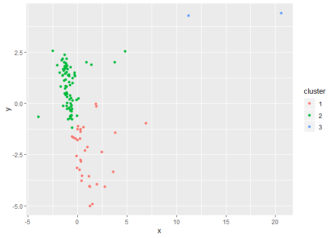

```r
worldData %>% .[,-1] %>% scale() %>% prcomp() -> pca
data.frame(x = pca$x[,1], y = pca$x[,2], cluster = as.factor(clustered$cluster)) %>% ggplot(aes(x = x, y = y, color = cluster)) + geom_point(stat = "identity")
```

۸. با استفاده از داده روشی برای پیش بینی رشد اقتصادی ایران در سال آینده ارائه دهید.

```r
data %>% filter(`Country Name` == "Iran, Islamic Rep.",`Indicator Code` %in%  Indicator) %>%
  gather('year', 'val',`1960`:`2017`) %>% filter(!is.na(val)) %>% select(`Indicator Code`,year,val) %>% spread("Indicator Code","val") %>% na.omit() %>% mutate(year = as.numeric(year)) %>% lm(formula = NY.GDP.MKTP.KD.ZG ~ year) -> model
model %>% summary()
```

```
##
## Call:
## lm(formula = NY.GDP.MKTP.KD.ZG ~ year, data = .)
##
## Residuals:
##      Min       1Q   Median       3Q      Max
## -10.1348  -3.0162  -0.1962   2.5105  11.3128
##
## Coefficients:
##             Estimate Std. Error t value Pr(>|t|)
## (Intercept) 307.8939   280.7834   1.097    0.285
## year         -0.1517     0.1401  -1.083    0.291
##
## Residual standard error: 4.677 on 21 degrees of freedom
## Multiple R-squared:  0.05291,    Adjusted R-squared:  0.007807
## F-statistic: 1.173 on 1 and 21 DF,  p-value: 0.291
```

```r
predict(model, data.frame(year = c(2019)))
```

```
##        1
## 1.628372
```

۹. سوالهای ۵ تا ۷ را ابتدا برای ۲۰ شاخص سلامت سپس بر حسب ۲۰ شاخص آموزشی تکرار کنید.

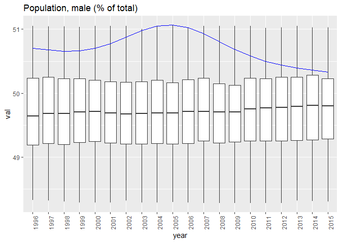

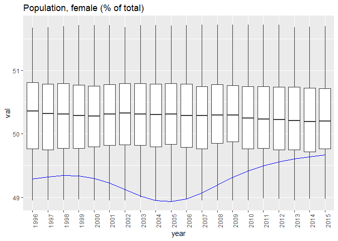

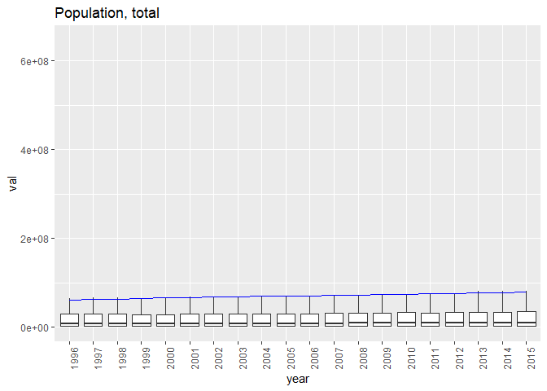

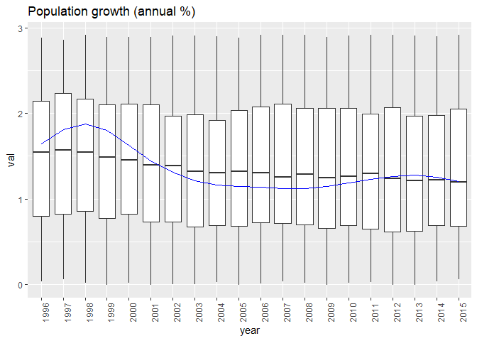

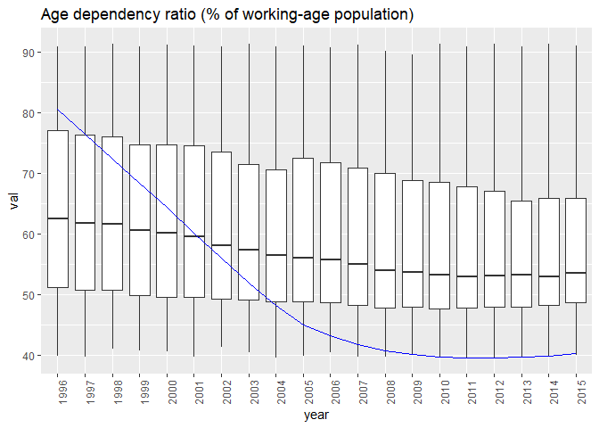

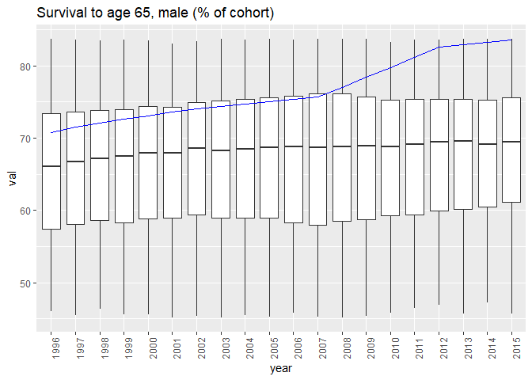

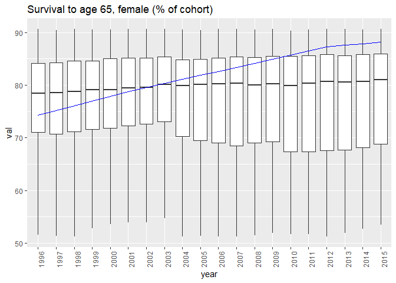

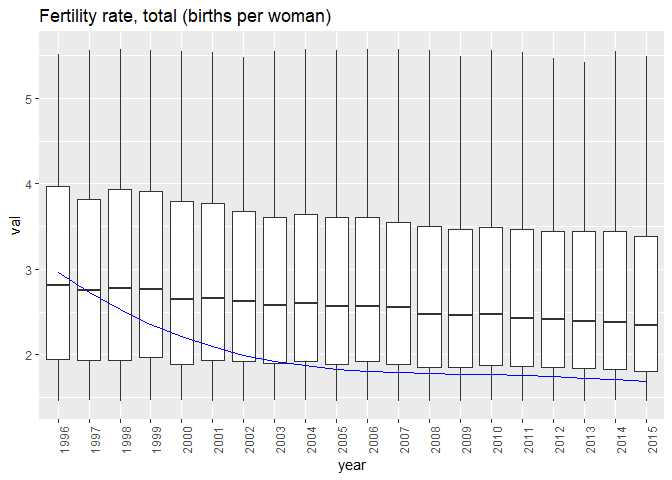

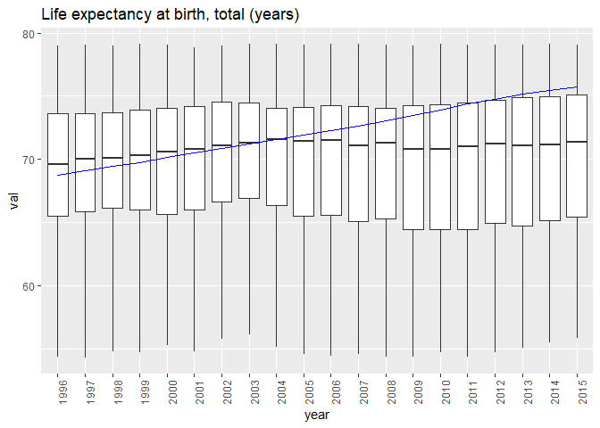

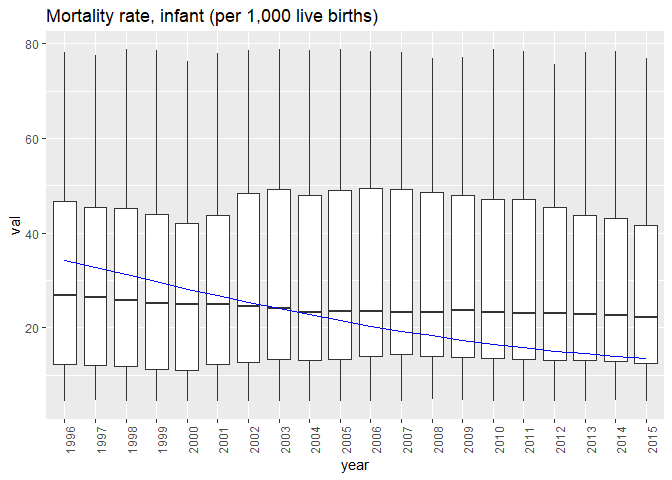

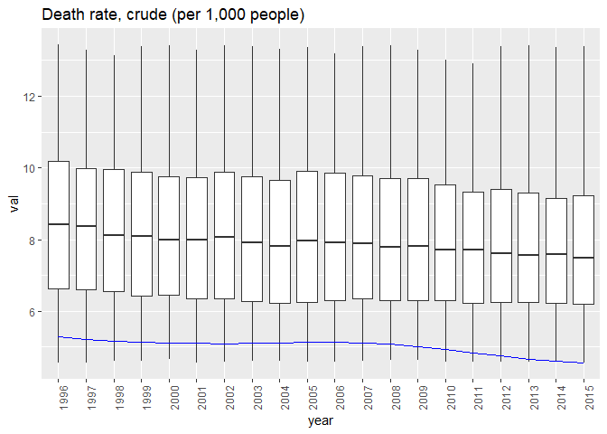

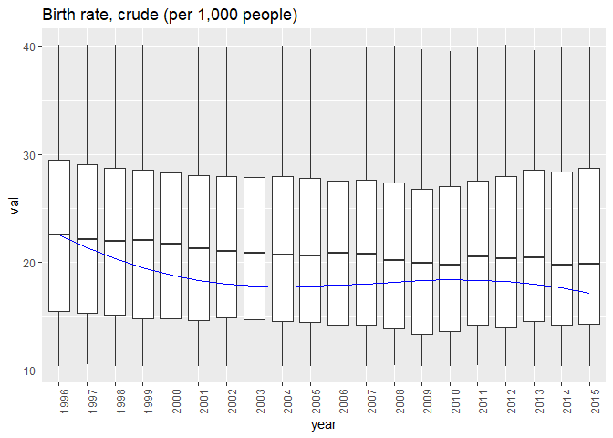

[5 more figures not shown]

```r
Indicatortemp2 = c(
  "SP.UWT.TFRT",
  "SP.REG.DTHS.ZS",
  "SP.REG.BRTH.ZS",
  "SP.POP.TOTL.MA.ZS",
  "SP.POP.TOTL.FE.ZS",
  "SP.POP.TOTL",
  "SP.POP.GROW",
  "SP.POP.DPND",
  "SP.POP.BRTH.MF",
  "SP.MTR.1519.ZS",
  "SP.M18.2024.FE.ZS",
  "SP.HOU.FEMA.ZS",
  "SP.DYN.WFRT",
  "SP.DYN.TO65.MA.ZS",
  "SP.DYN.TO65.FE.ZS",
  "SP.DYN.TFRT.IN",
  "SP.DYN.LE00.IN",
  "SP.DYN.IMRT.IN",
  "SP.DYN.CONM.ZS",
  "SP.DYN.CDRT.IN",
  "SP.DYN.CBRT.IN",
  "SP.DTH.REPT.ZS",
  "SP.ADO.TFRT",
  "SN.ITK.VITA.ZS",
  "SN.ITK.SALT.ZS",
  "SN.ITK.DFCT",
  "SN.ITK.DEFC.ZS",
  "SM.POP.TOTL.ZS",
  "SM.POP.TOTL",
  "SM.POP.REFG.OR",
  "SM.POP.REFG",
  "SM.POP.NETM",
  "SH.VAC.TTNS.ZS",
  "SH.UHC.OOPC.25.ZS",
  "SH.UHC.OOPC.25.TO",
  "SH.UHC.OOPC.10.ZS")
k = 0;
Indicator2 = c()
for(code in  Indicatortemp2){
  if(k == 20)
    break();
  IndicatorName = series %>% filter(`Series Code` == code) %>% .$`Indicator Name` %>% .[1]
  worldData = data %>% filter(`Indicator Code` == code) %>% select(`Country Name` , `1996`:`2015`) %>% gather('year','val',`1996`:`2015`) %>% filter(!is.na(val))
  IranData = worldData %>% filter(`Country Name` == "Iran, Islamic Rep.")
  if(length(IranData$val) < 20)
    next()
  p = ggplot() + geom_boxplot(data = worldData,aes(x = year,y=val),outlier.colour = NA) +
    geom_line(data = IranData,aes(x=year,y=val,group = 1),color = "blue") +
    theme(axis.text.x = element_text(angle = 90, hjust = 1)) +
    ggtitle(IndicatorName) +
    scale_y_continuous(limits = c(min(quantile(worldData$val, 0.1),min(IranData$val)),max(quantile(worldData$val, 0.9),max(IranData$val))))
  print(p)
   Indicator2 = c(code ,  Indicator2)
  k = k + 1
}
```

```r
data %>% filter(`Indicator Code` %in%  Indicator2) %>% gather('year','val',`1960`:`2017`) %>% filter(!is.na(val)) %>%
  mutate(year = as.numeric(year)) %>% arrange(year) %>% group_by(`Country Name`,`Indicator Code`) %>% summarise(val = last(val)) %>% spread('Indicator Code','val') %>% drop_na() -> worldData
worldData %>% .[,-1] %>% scale() %>% kmeans(centers = 3,nstart = 20) %>% .$cluster %>%
  data.frame(Country = worldData$`Country Name`,cluster = .) -> clustered
cluster1 = ""
cluster2 = ""
cluster3 = ""
for(i in 1:length(clustered$Country)){
  if(clustered[i,2] == 1){
    cluster1 = paste(clustered[i,1],cluster1,sep = " , ")
  }
  if(clustered[i,2] == 2){
    cluster2 = paste(clustered[i,1],cluster2,sep = " , ")
  }
  if(clustered[i,2] == 3){
    cluster3 = paste(clustered[i,1],cluster3,sep = " , ")
  }
}
print("cluster 1:")
```

```
## [1] "cluster 1:"
```

```r
cluster1
```

```
## [1] "Vietnam , Venezuela, RB , Vanuatu , Turkey , Tunisia , Thailand , Suriname , Sri Lanka , South Asia (IDA & IBRD) , South Asia , South Africa , Solomon Islands , Small states , Philippines , Peru , Paraguay , Pacific island small states , Other small states , Oman , Nicaragua , Nepal , Morocc…
```

```r
print("cluster 2:")
```

```
## [1] "cluster 2:"
```

```r
cluster2
```

```
## [1] "Middle income , Low & middle income , IDA & IBRD total , Early-demographic dividend , "
```

```r
print("cluster 3:")
```

```
## [1] "cluster 3:"
```

```r
cluster3
```

```
## [1] "Zimbabwe , Zambia , Yemen, Rep. , Uganda , Togo , Timor-Leste , Tanzania , Swaziland , Sudan , Sub-Saharan Africa (IDA & IBRD countries) , Sub-Saharan Africa (excluding high income) , Sub-Saharan Africa , Sierra Leone , Senegal , Rwanda , Pre-demographic dividend , Pakistan , Nigeria , Niger…
```

```r
paste("iran : cluster",clustered[52,2])
```

```
## [1] "iran : cluster 1"
```

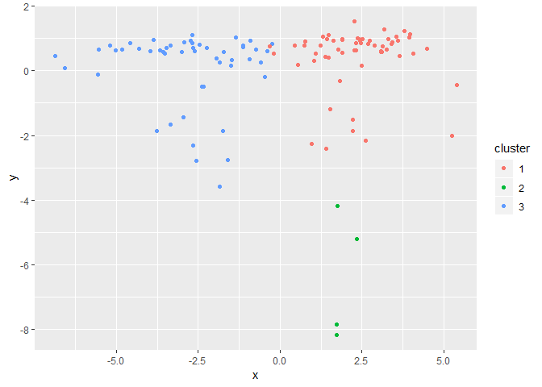

```r
worldData %>% .[,-1] %>% scale() %>% prcomp() -> pca
data.frame(x = pca$x[,1], y = pca$x[,2], cluster = as.factor(clustered$cluster)) %>% ggplot(aes(x = x, y = y, color = cluster)) + geom_point(stat = "identity")
```

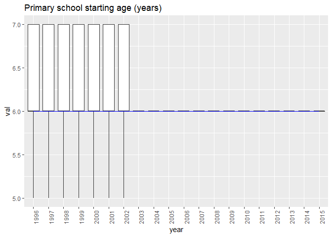

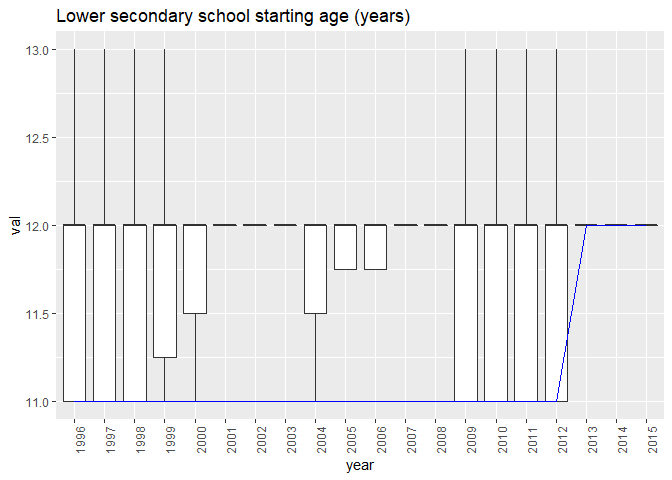

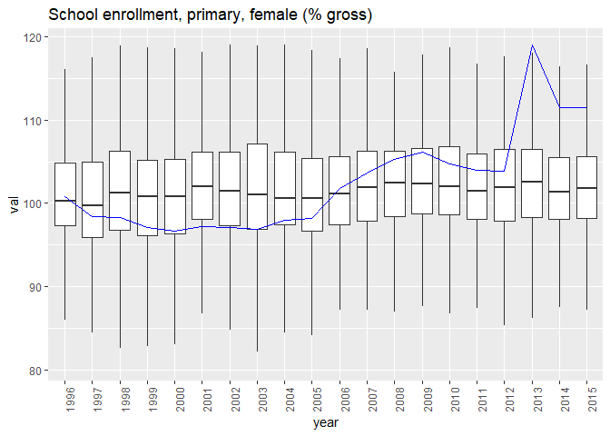

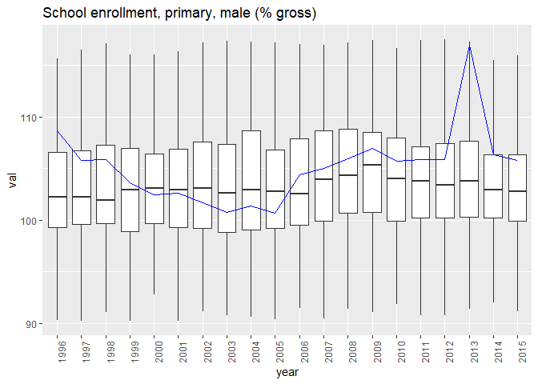

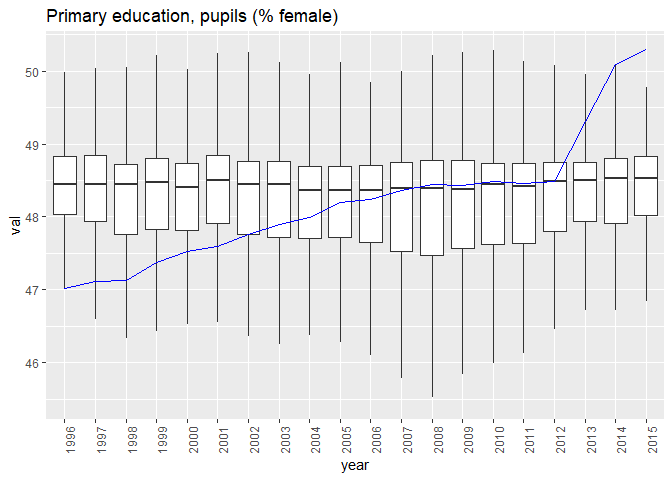

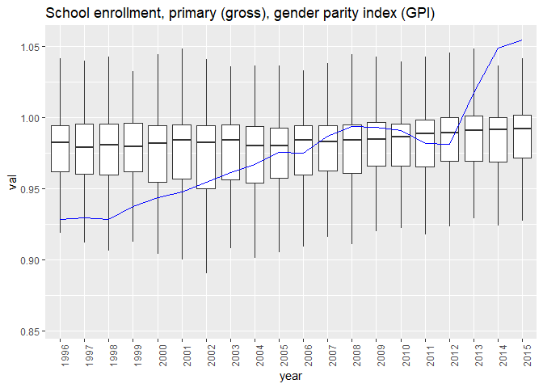

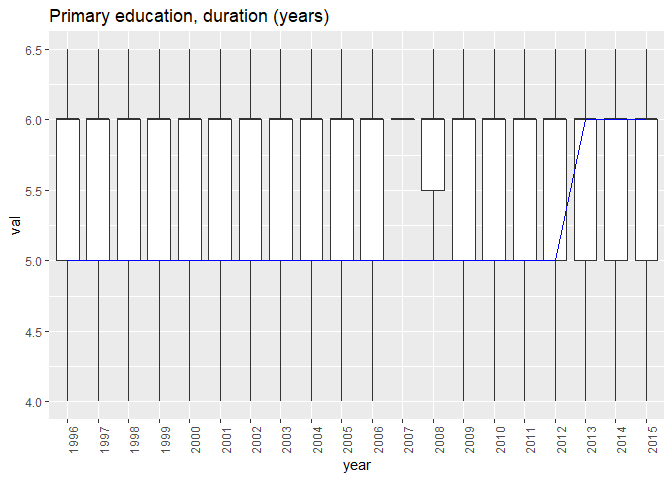

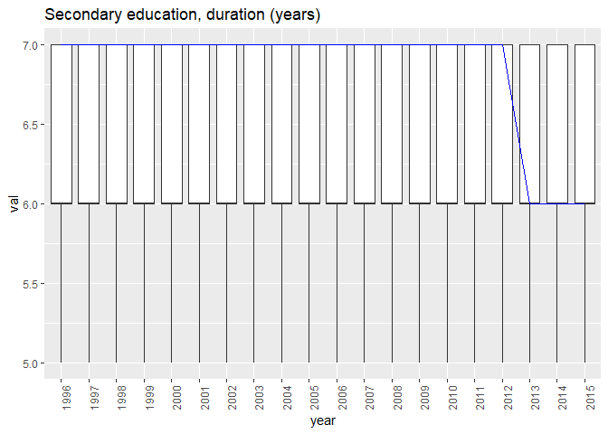

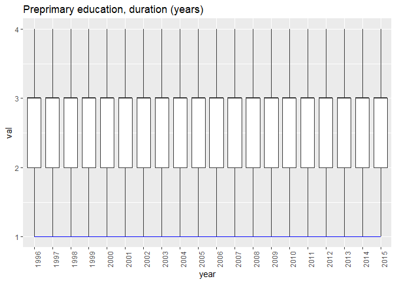

```r
Indicatortemp3 = c(
  "SE.PRM.AGES",
  "SE.SEC.AGES",
  "SE.PRM.ENRR.FE",
  "SE.PRM.ENRR.MA",
  "SE.PRM.ENRL.FE.ZS",
  "SE.ENR.TERT.FM.ZS",
  "SE.XPD.TOTL.GD.ZS",
  "SE.XPD.PRIM.PC.ZS",
  "SE.XPD.MTOT.ZS",
  "SE.XPD.MTER.ZS",
  "SE.SEC.ENRL.GC.FE.ZS",
  "SE.ENR.PRIM.FM.ZS",
  "SE.SEC.ENRR",
  "SE.ENR.SECO.FM.ZS",
  "SE.SEC.ENRL.FE.ZS",
  "SE.TER.ENRR",
  "SE.PRE.ENRR",
  "SE.PRM.GINT.FE.ZS",
  "SE.PRM.GINT.MA.ZS",
  "SE.PRM.REPT.ZS",
  "SE.XPD.TOTL.GD.ZS",
  "SE.XPD.TOTL.GB.ZS",
  "SE.XPD.TERT.ZS",
  "SE.XPD.TERT.PC.ZS",
  "SE.XPD.SECO.ZS",
  "SE.XPD.SECO.PC.ZS",
  "SE.XPD.PRIM.ZS",
  "SE.PRM.DURS",
  "SE.SEC.DURS",
  "SE.PRE.DURS",
  "SE.XPD.MSEC.ZS",
  "SE.XPD.MPRM.ZS",
  "SE.XPD.CTOT.ZS",
  "SE.XPD.CTER.ZS",
  "SE.XPD.CSEC.ZS",
  "SE.XPD.CPRM.ZS",
  "SE.TER.TCHR.FE.ZS",
  "SE.TER.ENRR",
  "SE.TER.ENRL.TC.ZS",
  "SE.TER.CUAT.ST.ZS"
)
k = 0;
Indicator3 = c()
for(code in  Indicatortemp3){
  if(k == 20)
    break();
  IndicatorName = series %>% filter(`Series Code` == code) %>% .$`Indicator Name` %>% .[1]
  worldData = data %>% filter(`Indicator Code` == code) %>% select(`Country Name` , `1996`:`2015`) %>% gather('year','val',`1996`:`2015`) %>% filter(!is.na(val))
  IranData = worldData %>% filter(`Country Name` == "Iran, Islamic Rep.")
  if(length(IranData$val) < 20)
    next()
  p = ggplot() + geom_boxplot(data = worldData,aes(x = year,y=val),outlier.colour = NA) +
    geom_line(data = IranData,aes(x=year,y=val,group = 1),color = "blue") +
    theme(axis.text.x = element_text(angle = 90, hjust = 1)) +
    ggtitle(IndicatorName) +
    scale_y_continuous(limits = c(min(quantile(worldData$val, 0.1),min(IranData$val)),max(quantile(worldData$val, 0.9),max(IranData$val))))
  print(p)
   Indicator3 = c(code ,  Indicator3)
  k = k + 1
}
```

```r
data %>% filter(`Indicator Code` %in%  Indicator3) %>% gather('year','val',`1960`:`2017`) %>% filter(!is.na(val)) %>%
  mutate(year = as.numeric(year)) %>% arrange(year) %>% group_by(`Country Name`,`Indicator Code`) %>% summarise(val = last(val)) %>% spread('Indicator Code','val') %>% drop_na() -> worldData
worldData %>% .[,-1] %>% scale() %>% kmeans(centers = 3) %>% .$cluster %>%
  data.frame(Country = worldData$`Country Name`,cluster = .) -> clustered
cluster1 = ""
cluster2 = ""
cluster3 = ""
for(i in 1:length(clustered$Country)){
  if(clustered[i,2] == 1){
    cluster1 = paste(clustered[i,1],cluster1,sep = " , ")
  }
  if(clustered[i,2] == 2){
    cluster2 = paste(clustered[i,1],cluster2,sep = " , ")
  }
  if(clustered[i,2] == 3){
    cluster3 = paste(clustered[i,1],cluster3,sep = " , ")
  }
}
print("cluster 1:")
```

```
## [1] "cluster 1:"
```

```r
cluster1
```

```
## [1] "Yemen, Rep. , Sudan , South Sudan , Somalia , Pakistan , Niger , Mali , Iraq , Guinea , Eritrea , Djibouti , Chad , Central African Republic , Angola , Afghanistan , "
```

```r
print("cluster 2:")
```

```
## [1] "cluster 2:"
```

```r
cluster2
```

```
## [1] "West Bank and Gaza , Vietnam , Uzbekistan , United Arab Emirates , Ukraine , Turkmenistan , Turkey , Tajikistan , Sri Lanka , Slovak Republic , Serbia , San Marino , Russian Federation , Romania , Nepal , Myanmar , Montenegro , Mongolia , Moldova , Madagascar , Macedonia, FYR , Lithuania , L…
```

```r
print("cluster 3:")
```

```
## [1] "cluster 3:"
```

```r
cluster3
```

```
## [1] "Zimbabwe , Zambia , Venezuela, RB , Vanuatu , Uruguay , United States , United Kingdom , Uganda , Tuvalu , Tunisia , Trinidad and Tobago , Tonga , Togo , Timor-Leste , Thailand , Tanzania , Syrian Arab Republic , Switzerland , Sweden , Swaziland , Suriname , St. Vincent and the Grenadines , …
```

```r
paste("iran : cluster",clustered[52,2])
```

```
## [1] "iran : cluster 3"
```

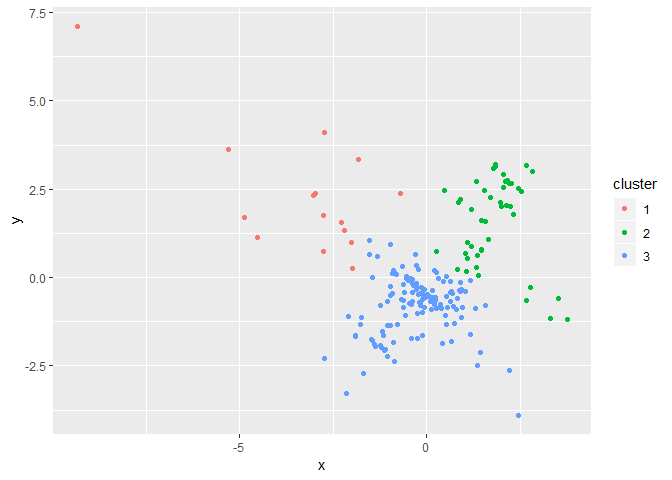

```r
worldData %>% .[,-1] %>% scale() %>% prcomp() -> pca
data.frame(x = pca$x[,1], y = pca$x[,2], cluster = as.factor(clustered$cluster)) %>% ggplot(aes(x = x, y = y, color = cluster)) + geom_point(stat = "identity")
```

۱۰. کشورهای دنیا را بر حسب ۶۰ شاخص اقتصادی، سلامت و آموزش با روش سلسله مراتبی خوشه بندی کرده و دندروگرام آن را رسم نمایید. اگر داده ها بر سه دسته تقسیم شوند ایران در کدام دسته می گنجد؟

```r
AllIndicator = c(Indicator,Indicator2,Indicator3)
data %>% filter(`Indicator Code` %in%  AllIndicator) %>% select(-X63) %>% gather('year','val',`1960`:`2017`) %>%
  filter(!is.na(val)) %>% mutate(year = as.numeric(year)) %>% arrange(year) %>%
  group_by(`Country Name`,`Indicator Code`) %>% summarise(val = last(val)) %>% spread('Indicator Code','val') %>%
  drop_na() %>% ungroup() -> worldData
row.names(worldData) = worldData$`Country Name`
```

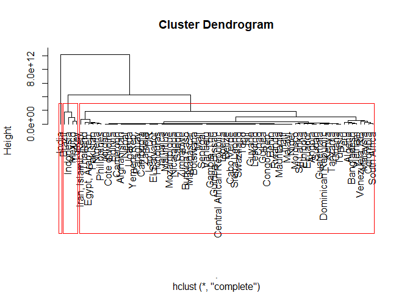

```r
worldData = worldData %>% select(-c(1,2))
stats::dist(worldData[,-1],method = "euclidean") -> dist
dist %>% hclust(method = "complete")->hclust
hclust %>% plot(hang = -1,labels=worldData %>% row.names())
rect.hclust(hclust, 3)
```

میتوان دید که ایران در دسته سوم قرار دارد.

۱۱. سه یافته جالب از داده ها استخراج کنید.

آیا بین سطح تحصیلات و سن ازدواج زنان رابطه معنا داری وجود دارد؟

```r
data %>% filter(`Indicator Code` %in% c("SP.M15.2024.FE.ZS","SE.SEC.CUAT.UP.ZS")) %>%
  gather('year','val',`1960`:`2017`) %>% filter(!is.na(val)) %>% select(`Country Name`,`Indicator Code`,year,val) %>%
  mutate(year = as.numeric(year)) %>% group_by(`Country Name`,`Indicator Code`) %>%
  arrange(year) %>% summarise(val = last(val)) %>% spread(`Indicator Code`,val) %>% na.omit() %>%
  select(country = 1,education = 2,marriage = 3) -> t1

cor.test(t1$marriage,t1$education)
```

```
##
##  Pearson's product-moment correlation
##
## data:  t1$marriage and t1$education
## t = -4.564, df = 70, p-value = 2.088e-05
## alternative hypothesis: true correlation is not equal to 0
## 95 percent confidence interval:
##  -0.6395917 -0.2780604
## sample estimates:
##        cor
## -0.4788805
```

مصرف انرژی با GDP رابطه دارد.

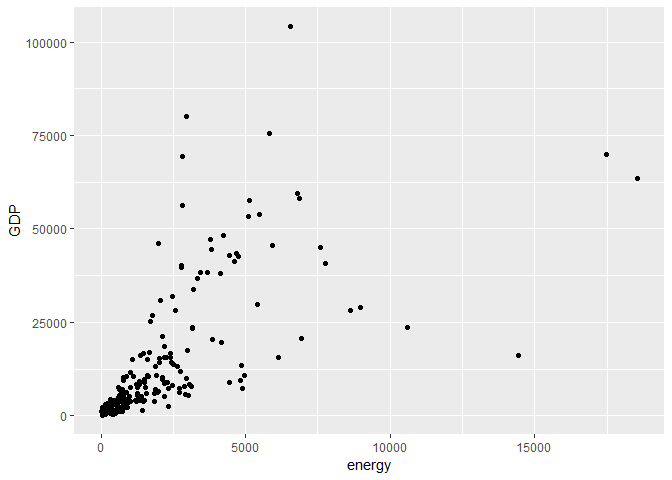

```r
data %>% filter(`Indicator Code` %in% c("NY.GDP.PCAP.CD","EG.USE.PCAP.KG.OE")) %>%
  gather('year','val',`1960`:`2017`) %>% filter(!is.na(val)) %>% select(`Country Name`,`Indicator Code`,year,val) %>%
  mutate(year = as.numeric(year)) %>% group_by(`Country Name`,`Indicator Code`) %>%
  arrange(year) %>% summarise(val = last(val)) %>% spread(`Indicator Code`,val) %>% na.omit() %>%
  select(country = 1,energy = 2,GDP = 3) -> t1
ggplot() + geom_point(data = t1,aes(x = energy,y=GDP))
```

```r
cor.test(t1$energy,t1$GDP)
```

```
##
##  Pearson's product-moment correlation
##
## data:  t1$energy and t1$GDP
## t = 13.143, df = 214, p-value < 2.2e-16
## alternative hypothesis: true correlation is not equal to 0
## 95 percent confidence interval:
##  0.5872194 0.7361400
## sample estimates:
##       cor
## 0.6683228
```